# 04_SMART_Marginal_Fitting_Current_Job_Rank

```python
%matplotlib inline
```

**Marginal Fitting: Current Job Rank**

**Comments**:

- *current_job_rank* is fixed to match the proportions per age in the 2017 SynPop
- The choice of persons to fix is done with a probability model based on their *is_employed* and *current_edu*

```python
import logging
import os
import sys

from matplotlib import pyplot as plt
import pandas as pd
```

```python
sys.path.append(r'X:\90_Persoenlich\u229285\dev\SynPopToolbox')
```

```python
from synpop.visualisations import save_figure, plot_multi_class_feature_per_age, plot_ct1, plot_ct2, plot_ct3
from synpop import marginal_fitting, utils
from synpop.synpop import Persons
from synpop.marginals import FSO_ActivePopPredictionsClient
```

```python
logger = logging.getLogger()
logger.setLevel(logging.DEBUG)  # Set logging level: WARNING, INFO, DEBUG
```

# Settings

```python
YEAR_IST = 2017
YEAR = 2040

DATA_DIR_IST = r'\\k13536\mobi\10_Daten\SynPop\2017\190813_CH_2017_BEST1\02_preprocessed'
SYNPOP_PERSONS_FILE_IST = os.path.join(DATA_DIR_IST, 'persons_{}.pickle.gzip'.format(YEAR_IST))

DATA_DIR = r'\\k13536\mobi\10_Daten\SynPop\2040\02_preprocessed'
SYNPOP_PERSONS_FILE = os.path.join(DATA_DIR, 'persons_{}.pickle.gzip'.format(YEAR))

FIXED_ATTRIBUTES_DIR = 'outputs'
```

**Export Settings**

```python
SAVE_OUTPUTS = True
OUTPUT_DIR = './outputs'
FIG_FORMAT = 'png'
FIG_DPI = 150
FIG_BBOX_INCHES = 'tight'
FIG_PAD_INCHES = 0.2
```

```python
utils.create_dir(OUTPUT_DIR)
```

```
2020-04-22 10:08:46,894 - INFO - synpop.utils: "./outputs" exists already
```

# Loading Data

## SynPop

```python
COLUMNS_OF_INTEREST = ['person_id', 'level_of_employment', 'position_in_bus', 'position_in_edu', 'age', 'location_id',
                       'is_employed', 'loe_group', 'current_edu', 'current_job_rank', 'is_apprentice',
                       'KT', 'N_KT', 'ID_Gem', 'N_Gem', 'KT_full' ]
```

**Scenario Year**

```python
SYNPOP_PERSONS_FILE
```

```
'\\\\k13536\\mobi\\10_Daten\\SynPop\\2040\\02_preprocessed\\persons_2040.pickle.gzip'
```

```python
%%time
synpop_persons = Persons(YEAR)
synpop_persons.load_pickle(SYNPOP_PERSONS_FILE)

fixed_edu = pd.read_pickle(os.path.join(FIXED_ATTRIBUTES_DIR, f'fixed_current_edu_SMART.pickle.gzip'), compression='gzip')
synpop_persons.overwrite_column('current_edu', fixed_edu)

persons = synpop_persons.data[COLUMNS_OF_INTEREST].copy(deep=True)

del synpop_persons
```

```
2020-04-22 10:08:46,948 - INFO - synpop.synpop: Loading \\k13536\mobi\10_Daten\SynPop\2040\02_preprocessed\persons_2040.pickle.gzip ...
2020-04-22 10:09:05,169 - INFO - synpop.synpop: Table persons loaded with 10037464 rows.
2020-04-22 10:09:06,531 - INFO - synpop.synpop: Overwriting "current_edu" with new values ...
2020-04-22 10:09:23,960 - DEBUG - synpop.synpop: Columns "current_edu" has been dropped.
2020-04-22 10:09:35,714 - INFO - synpop.synpop: "current_edu" has been overwritten.
```

```
Wall time: 56.3 s
```

```python
persons.head()
```

|  | person_id | level_of_employment | position_in_bus | position_in_edu | age | location_id | is_employed | loe_group | current_edu | current_job_rank | is_apprentice | KT | N_KT | ID_Gem | N_Gem | KT_full |
| --- | --- | --- | --- | --- | --- | --- | --- | --- | --- | --- | --- | --- | --- | --- | --- | --- |
| 0 | 1 | 95 | employee | null | 62 | 220601003 | True | part-time | null | employee | False | 10 | FR | 2206 | Marly | Fribourg / Freiburg |
| 1 | 2 | 0 | unemployed | null | 78 | 24301026 | False | non-employed | null | null | False | 1 | ZH | 243 | Dietikon | Zürich |
| 2 | 4 | 100 | management | null | 56 | 662101042 | True | full-time | null | management | False | 25 | GE | 6621 | Genève | Genève |
| 3 | 5 | 100 | ceo | null | 48 | 24301003 | True | full-time | null | management | False | 1 | ZH | 243 | Dietikon | Zürich |
| 4 | 6 | 100 | employee | null | 46 | 24301003 | True | full-time | null | employee | False | 1 | ZH | 243 | Dietikon | Zürich |

**Year IST**

```python
SYNPOP_PERSONS_FILE_IST
```

```
'\\\\k13536\\mobi\\10_Daten\\SynPop\\2017\\190813_CH_2017_BEST1\\02_preprocessed\\persons_2017.pickle.gzip'
```

```python
%%time
synpop_persons_ist = Persons(YEAR_IST)
synpop_persons_ist.load_pickle(SYNPOP_PERSONS_FILE_IST)

persons_ist = synpop_persons_ist.data[COLUMNS_OF_INTEREST].copy(deep=True)

del synpop_persons_ist
```

```
2020-04-22 10:09:43,322 - INFO - synpop.synpop: Loading \\k13536\mobi\10_Daten\SynPop\2017\190813_CH_2017_BEST1\02_preprocessed\persons_2017.pickle.gzip ...
2020-04-22 10:10:10,523 - INFO - synpop.synpop: Table persons loaded with 8560151 rows.
```

```
Wall time: 33.4 s
```

```python
print('Imported data:')
print('persons DataFrame for {}: {}'.format(YEAR_IST, persons_ist.shape))
print('persons DataFrame for {}: {}'.format(YEAR, persons.shape))
```

```
Imported data:
persons DataFrame for 2017: (8560151, 16)
persons DataFrame for 2040: (10037464, 16)
```

## FSO Data

- In notebook 05a, the *level_of_employment* will be fitted to the BFS predictions.
- In order for the cross-tables to work, the sum of *current_job_rank* that are either *employee*, *management* or *apprentice* must match the number of employed people.

```python
# This is a function that is only used for this Notebook so stays here
def prepare_bfs_level_of_activity_marginal_table(bfs_avg_active_people_by_age, all_ages_set, year):

    prop_active = (bfs_avg_active_people_by_age.reindex(all_ages_set, fill_value=0) / 100).to_frame()
    prop_inactive = 1 - prop_active

    prop_active['is_employed'] = True
    prop_active = prop_active.reset_index().set_index(['age', 'is_employed'])
    prop_inactive['is_employed'] = False
    prop_inactive = prop_inactive.reset_index().set_index(['age', 'is_employed'])

    bfs_prop_predictions = pd.concat([prop_active, prop_inactive]).sort_index()

    bfs_prop_predictions = bfs_prop_predictions.iloc[:, 0].rename(f'expected_ratios_{year}')
    return bfs_prop_predictions
```

*Scenario Year*

```python
active_pop_client = FSO_ActivePopPredictionsClient(granularity='age').load(YEAR)
active_pop_stats_by_age = active_pop_client.stats

all_ages = set(persons['age'].unique())
bfs_predicted_ratio = prepare_bfs_level_of_activity_marginal_table(active_pop_stats_by_age['avg_active_people'], all_ages, YEAR)
```

```
2020-04-22 10:10:17,759 - INFO - numexpr.utils: NumExpr defaulting to 8 threads.
```

### FSO without job seekers

- BFS predicts active people which includes job seekers.
- In MOBi, all working people go to a job, job seekers have level_of_employment = 0.
- Based on the BFS own definition, the unemployement rate in 2017 is about 4.5%.

References:

- https://www.seco.admin.ch/seco/fr/home/wirtschaftslage---wirtschaftspolitik/Wirtschaftslage/Arbeitslosenzahlen.html
- https://www.bfs.admin.ch/bfs/fr/home/statistiques/travail-remuneration/activite-professionnelle-temps-travail/personnes-actives/scenarios-population-active.assetdetail.9687328.html

```python
# The very conservative assuption of 2% unemployement has been made for 2040.
UNEMPLOYMENT_RATE = 0.02

bfs_without_unemployed = bfs_predicted_ratio.copy(deep=True)
bfs_without_unemployed.loc[:, True] = bfs_without_unemployed.loc[:, True].values * (1 - UNEMPLOYMENT_RATE)
bfs_without_unemployed.loc[:, False] = (1 - bfs_without_unemployed.loc[:, True]).values
```

# Examining SynPop-raw

```python
COLOUR_DICT = {'employee': 'C0', 'management': 'C1', 'apprentice': 'C3',  'null': 'grey'}
```

```python
ORDERED_CATEGORIES = list(persons['current_job_rank'].cat.categories)
```

## Global Counts

```python
%%time
summary_table = marginal_fitting.compute_comparison_summary(persons, persons_ist,
                                                            YEAR, YEAR_IST,
                                                            groupby='current_job_rank')
```

```
Wall time: 13.7 s
```

```python
print('As reference, the total population growth is: {:.2f}'.format(persons.shape[0] / persons_ist.shape[0]))
summary_table
```

```
As reference, the total population growth is: 1.17
```

| current_job_rank | counts_2017 | counts_2040 | growth | prop_2017 | prop_2040 |
| --- | --- | --- | --- | --- | --- |
| apprentice | 184450 | 406485 | 2.20 | 0.02 | 0.04 |
| employee | 2962016 | 4286371 | 1.45 | 0.35 | 0.43 |
| management | 1680773 | 1513093 | 0.90 | 0.20 | 0.15 |
| null | 3732912 | 3831515 | 1.03 | 0.44 | 0.38 |

## Marginals Per Age

```python
%%time
marginals = marginal_fitting.compute_ist_vs_scenario_marginal_counts(persons, persons_ist,
                                                                     YEAR, YEAR_IST,
                                                                     feature='current_job_rank',
                                                                     control_level_list=['age'])
```

```
Wall time: 18.9 s
```

**Scenario Year**

```python
counts_per_cat = (marginals
                  .reset_index()
                  .pivot(index='age', columns='current_job_rank', values=f'counts_{YEAR}')
                  )
counts_per_cat = counts_per_cat[ORDERED_CATEGORIES]
```

```
2020-04-22 10:10:53,200 - INFO - root: Figure saved to file : ./outputs\04_SynPop2040_raw_current_job_rank_by_age.png
```

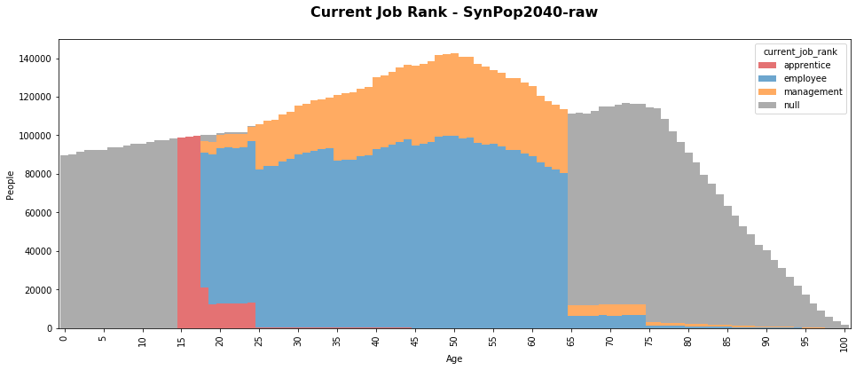

```python
title = f'Current Job Rank - SynPop{YEAR}-raw'

ax = plot_multi_class_feature_per_age(counts_per_cat, colour_dict=COLOUR_DICT, ymax=150_000, title=title)

save_figure(SAVE_OUTPUTS, f'04_SynPop{YEAR}_raw_current_job_rank_by_age.{FIG_FORMAT}',
            OUTPUT_DIR, FIG_DPI, FIG_FORMAT, FIG_BBOX_INCHES, FIG_PAD_INCHES)
```

**Year IST**

```python
counts_per_cat_ist = (marginals
                      .reset_index()
                      .pivot(index='age', columns='current_job_rank', values=f'counts_{YEAR_IST}')
                      )
counts_per_cat_ist = counts_per_cat_ist[ORDERED_CATEGORIES]
```

```
2020-04-22 10:10:57,273 - INFO - root: Figure saved to file : ./outputs\04_SynPop2017_current_job_rank_by_age.png
```

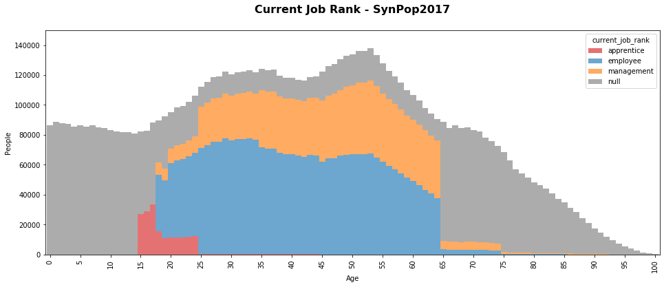

```python
title = f'Current Job Rank - SynPop{YEAR_IST}'

ax = plot_multi_class_feature_per_age(counts_per_cat_ist, colour_dict=COLOUR_DICT, ymax=150_000, title=title)

save_figure(SAVE_OUTPUTS, f'04_SynPop{YEAR_IST}_current_job_rank_by_age.{FIG_FORMAT}',
            OUTPUT_DIR, FIG_DPI, FIG_FORMAT, FIG_BBOX_INCHES, FIG_PAD_INCHES)
```

## Cross-Relationships

**Scenario Year**

**CT1**

```
2020-04-22 10:11:10,182 - INFO - root: Figure saved to file : ./outputs\04_CT1_SynPop2040_raw.png
```

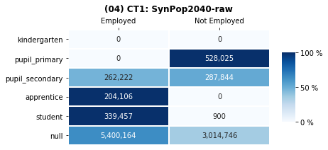

```python
ax, _ = plot_ct1(persons, title=f'(04) CT1: SynPop{YEAR}-raw')

save_figure(SAVE_OUTPUTS, f'04_CT1_SynPop{YEAR}_raw.{FIG_FORMAT}',
            OUTPUT_DIR, FIG_DPI, FIG_FORMAT, FIG_BBOX_INCHES, FIG_PAD_INCHES)
```

**CT2**

```
2020-04-22 10:11:20,544 - INFO - root: Figure saved to file : ./outputs\04_CT2_SynPop2040_raw.png
```

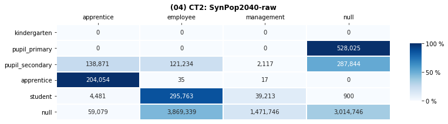

```python
ax, _ = plot_ct2(persons, title=f'(04) CT2: SynPop{YEAR}-raw')

save_figure(SAVE_OUTPUTS, f'04_CT2_SynPop{YEAR}_raw.{FIG_FORMAT}',
            OUTPUT_DIR, FIG_DPI, FIG_FORMAT, FIG_BBOX_INCHES, FIG_PAD_INCHES)
```

**CT3**

```
2020-04-22 10:11:31,438 - INFO - root: Figure saved to file : ./outputs\04_CT3_SynPop2040_raw.png
```

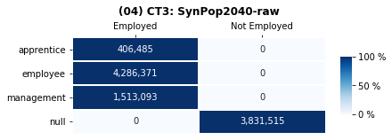

```python
ax, ct = plot_ct3(persons, title=f'(04) CT3: SynPop{YEAR}-raw')

save_figure(SAVE_OUTPUTS, f'04_CT3_SynPop{YEAR}_raw.{FIG_FORMAT}',
            OUTPUT_DIR, FIG_DPI, FIG_FORMAT, FIG_BBOX_INCHES, FIG_PAD_INCHES)
```

**Year IST**

**CT1**

```
2020-04-22 10:11:40,638 - INFO - root: Figure saved to file : ./outputs\04_CT1_SynPop2017.png
```

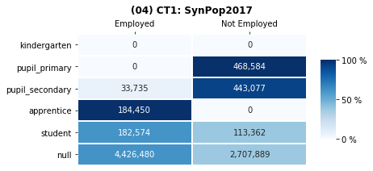

```python
ax, _ = plot_ct1(persons_ist, title=f'(04) CT1: SynPop{YEAR_IST}')

save_figure(SAVE_OUTPUTS, f'04_CT1_SynPop{YEAR_IST}.{FIG_FORMAT}',
            OUTPUT_DIR, FIG_DPI, FIG_FORMAT, FIG_BBOX_INCHES, FIG_PAD_INCHES)
```

**CT2**

```
2020-04-22 10:11:49,056 - INFO - root: Figure saved to file : ./outputs\04_CT2_SynPop2017.png
```

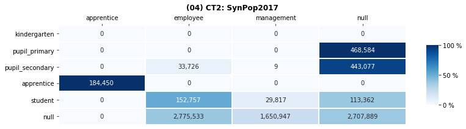

```python
ax, _ = plot_ct2(persons_ist, title=f'(04) CT2: SynPop{YEAR_IST}')

save_figure(SAVE_OUTPUTS, f'04_CT2_SynPop{YEAR_IST}.{FIG_FORMAT}',
            OUTPUT_DIR, FIG_DPI, FIG_FORMAT, FIG_BBOX_INCHES, FIG_PAD_INCHES)
```

**CT3**

```
2020-04-22 10:11:58,504 - INFO - root: Figure saved to file : ./outputs\04_CT3_SynPop2017.png
```

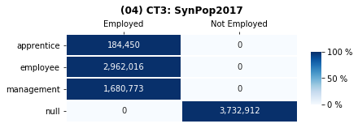

```python
ax, ct = plot_ct3(persons_ist, title=f'(04) CT3: SynPop{YEAR_IST}')

save_figure(SAVE_OUTPUTS, f'04_CT3_SynPop{YEAR_IST}.{FIG_FORMAT}',
            OUTPUT_DIR, FIG_DPI, FIG_FORMAT, FIG_BBOX_INCHES, FIG_PAD_INCHES)
```

# Fixing Methodology

## Expected Counts

```python
%%time
marginals = marginal_fitting.compute_ist_vs_scenario_marginal_summary_table(persons, persons_ist,
                                                                            YEAR, YEAR_IST,
                                                                            'current_job_rank',
                                                                            ['age']
                                                                           )
```

```
2020-04-22 10:12:20,387 - INFO - synpop.marginal_fitting: The following segments have no data in ist and will stay untouched: Int64Index([110, 111, 112, 113, 114, 116, 117, 118, 119, 120, 121, 122, 123,
            124, 125, 126, 127, 128, 129, 131, 132],
           dtype='int64', name='age')
```

```
Wall time: 22.2 s
```

### Adapting the marginals to match BFS predictions

**Note:** Scaling up the 2017 proportions on the 2040 age pyramid is not enough:

- BFS predicts that more people will be working in 2040 (e.g. more women should be employed)
- The control totals for non-null job ranks have to be scaled up to match the BFS prediction for the number of active people
- Since we do not know much about how *apprentice* will evove, it is kept stable in this post fixing step.
- Control totals for *management* and *employee* are modulated for the number of *null* predicted by the BFS to be mached.

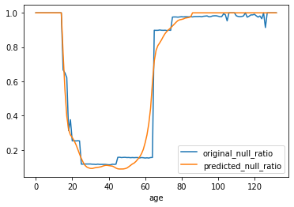

```python
original_nulls = marginals.reset_index().query('current_job_rank == "null"').set_index('age')[f'expected_counts_{YEAR}'].rename('original_nulls')
original_counts = marginals.reset_index().groupby('age')[f'expected_counts_{YEAR}'].sum().rename('original_counts')

original_null_ratio = (original_nulls / original_counts).rename('original_null_ratio')
bfs_pred_ratio = bfs_without_unemployed.reset_index().query('~is_employed').set_index('age')[f'expected_ratios_{YEAR}'].rename('predicted_null_ratio')
_ = pd.concat([original_null_ratio, bfs_pred_ratio],axis=1).plot()
```

```python
marginals_adapted = marginals.drop([f'deltas_{YEAR}'], axis=1).copy(deep=True)
```

**Setting the nulls to what would fit the BFS prediction**

```python
expected_nulls = (marginals.reset_index().groupby('age')[f'expected_counts_{YEAR}'].sum().rename('original_counts') * bfs_pred_ratio).astype(int)
delta_nulls = (original_nulls - expected_nulls).rename('delta_nulls')
original_employees = marginals_adapted.reset_index().query('current_job_rank == "employee"').set_index('age')[f'expected_counts_{YEAR}'].rename('original_employees')
original_management = marginals_adapted.reset_index().query('current_job_rank == "management"').set_index('age')[f'expected_counts_{YEAR}'].rename('original_management')
```

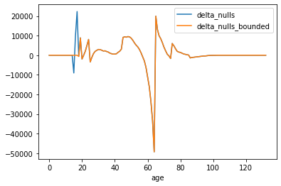

```python
# Because we componsate "nulls" only by "employee" or "management" (not "apprentice"), some age groups cannot be fixed perfectly.
# This is not really a problem, the quality is already much better with this simple-ish fix.
delta_nulls_bounded = -pd.concat([(original_management + original_employees), -delta_nulls], axis=1).min(axis=1)

# Adtitionally if there are 0 "employee" and 0 "management", none can be created!
# i.e. age 16, 17 which have only apprentice!
delta_nulls_bounded = delta_nulls_bounded.mask((original_management + original_employees) == 0, 0)
delta_nulls_bounded = delta_nulls_bounded.rename('delta_nulls_bounded')

_ = pd.concat([delta_nulls, delta_nulls_bounded], axis=1).plot()
```

```python
adapted_nulls = (original_nulls - delta_nulls_bounded).rename('adapted_nulls')

mask_nulls = marginals_adapted.index.get_level_values(1) == 'null'
marginals_adapted[f'expected_counts_{YEAR}'] = marginals_adapted[f'expected_counts_{YEAR}'].mask(mask_nulls, adapted_nulls)
```

**Compensating the difference in "null" with "employee" and "management"**

```python
# The ratio of employee over all employee & management defines how much employees marginals will be adapted.
employee_management_ratio = (original_employees / (original_employees + original_management)).fillna(0)
delta_employee = (delta_nulls_bounded * employee_management_ratio).round(0).astype(int)
delta_management = delta_nulls_bounded - delta_employee
```

```python
# At this point we have already made sure there are enough "employee" and "management"
# This is why delta_nulls is bounded.
adapted_employees = (original_employees + delta_employee).rename('adapted_employees')

mask_employee = marginals_adapted.index.get_level_values(1) == 'employee'
marginals_adapted[f'expected_counts_{YEAR}'] = marginals_adapted[f'expected_counts_{YEAR}'].mask(mask_employee, adapted_employees)
```

```python
adapted_management = (original_management + delta_management).rename('adapted_management')

mask_management = marginals_adapted.index.get_level_values(1) == 'management'
marginals_adapted[f'expected_counts_{YEAR}'] = marginals_adapted[f'expected_counts_{YEAR}'].mask(mask_management, adapted_management)
```

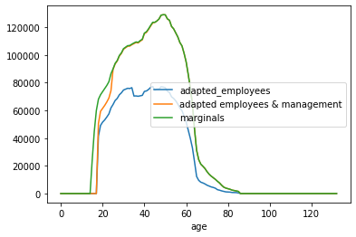

```python
# Sanity check:
bfs_employed_prediction = (marginals.reset_index().groupby('age')[f'expected_counts_{YEAR}'].sum().rename('original_counts') * (1-bfs_pred_ratio)).astype(int).rename('marginals')
_ = pd.concat([adapted_employees,
               (adapted_employees + adapted_management).rename('adapted employees & management'),
               bfs_employed_prediction
              ],
              axis=1).plot()
```

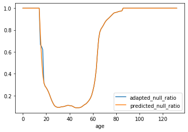

```python
# Sanity check:
adapted_nulls = marginals_adapted.reset_index().query('current_job_rank == "null"').set_index('age')[f'expected_counts_{YEAR}'].rename('adapted_nulls')
adapted_counts = marginals_adapted.reset_index().groupby('age')[f'expected_counts_{YEAR}'].sum().rename('adapted_counts')

original_null_ratio = (adapted_nulls / adapted_counts).rename('adapted_null_ratio')
bfs_pred_ratio = bfs_without_unemployed.reset_index().query('~is_employed').set_index('age')[f'expected_ratios_{YEAR}'].rename('predicted_null_ratio')
_ = pd.concat([original_null_ratio, bfs_pred_ratio],axis=1).plot()
```

```python
# Sanity check:
pop_per_age_before = marginals.groupby(level='age').sum()[f'expected_counts_{YEAR}']
pop_per_age_after = marginals_adapted.groupby(level='age').sum()[f'expected_counts_{YEAR}']

assert ((pop_per_age_after - pop_per_age_before) == 0).all(), 'The pop per age has changes after applying the new control totals!'
```

```python
expected_pop_counts = (marginals_adapted[f'expected_counts_{YEAR}'].rename('expected_counts')
                       .reset_index()
                       .pivot(index='age', columns='current_job_rank', values='expected_counts')
                       )[ORDERED_CATEGORIES]
```

```python
expected_pop_counts.head()
```

| current_job_rank age | apprentice | employee | management | null |
| --- | --- | --- | --- | --- |
| 0 | 0 | 0 | 0 | 89500 |
| 1 | 0 | 0 | 0 | 90094 |
| 2 | 0 | 0 | 0 | 91606 |
| 3 | 0 | 0 | 0 | 92288 |
| 4 | 0 | 0 | 0 | 92272 |

## Probabiltiy Model

```python
ct_job_ist = marginal_fitting.compute_cross_table(persons_ist,
                                                  main_feature='current_job_rank',
                                                  secondary_features=['current_edu', 'is_employed']
                                                  )
```

```python
ct_job_ist
```

| current_edu | current_job_rank is_employed | apprentice | employee | management | null |
| --- | --- | --- | --- | --- | --- |
| kindergarten | False | 0 | 0 | 0 | 0 |
|  | True | 0 | 0 | 0 | 0 |
| pupil_primary | False | 0 | 0 | 0 | 468584 |
|  | True | 0 | 0 | 0 | 0 |
| pupil_secondary | False | 0 | 0 | 0 | 443077 |
|  | True | 0 | 33726 | 9 | 0 |
| student | False | 0 | 0 | 0 | 113362 |
|  | True | 0 | 152757 | 29817 | 0 |
| apprentice | False | 0 | 0 | 0 | 0 |
|  | True | 184450 | 0 | 0 | 0 |
| null | False | 0 | 0 | 0 | 2707889 |
|  | True | 0 | 2775533 | 1650947 | 0 |

```python
%%time
person_proba = marginal_fitting.build_person_proba_with_from_cross_table(
    persons, ct_job_ist,
    merge_on=['current_edu', 'is_employed']
)
```

```
Wall time: 12.2 s
```

```python
person_proba.head()
```

| person_id | apprentice | employee | management | null |
| --- | --- | --- | --- | --- |
| 1 | 1.000000e-10 | 0.627029 | 0.372971 | 1.000000e-10 |
| 4 | 1.000000e-10 | 0.627029 | 0.372971 | 1.000000e-10 |
| 5 | 1.000000e-10 | 0.627029 | 0.372971 | 1.000000e-10 |
| 6 | 1.000000e-10 | 0.627029 | 0.372971 | 1.000000e-10 |
| 7 | 1.000000e-10 | 0.627029 | 0.372971 | 1.000000e-10 |

## Fixing...

The logging can be set to `INFO` or `DEBUG` (at the top of the notebook `logger.setLevel(logging.INFO)`) based on how much detail is needed!

```python
fixed_job = marginal_fitting.fix_categorical_feature(persons=persons,
                                                     feature='current_job_rank',
                                                     pop_segment_variables=['age'],
                                                     control_totals=expected_pop_counts,
                                                     person_proba=person_proba
                                                     )
```

[output not shown]

[output cut: 2042 more lines]

[output not shown]

```python
persons_fixed = persons.copy(deep=True)
persons_fixed = persons_fixed.drop('current_job_rank', axis=1)
persons_fixed = pd.merge(persons_fixed, fixed_job, left_on='person_id', right_index=True)

persons_fixed.shape
```

```
(10037464, 16)
```

# Examining SynPop+

## Global Counts

```python
%%time
summary_table_fixed = marginal_fitting.compute_comparison_summary(persons_fixed, persons_ist,
                                                                  YEAR, YEAR_IST,
                                                                  groupby='current_job_rank')
```

```
Wall time: 17.1 s
```

```python
print('As reference, the total population growth is: {:.2f}'.format(persons_fixed.shape[0] / persons_ist.shape[0]))
summary_table_fixed
```

```
As reference, the total population growth is: 1.17
```

| current_job_rank | counts_2017 | counts_2040 | growth | prop_2017 | prop_2040 |
| --- | --- | --- | --- | --- | --- |
| apprentice | 184450 | 204099 | 1.11 | 0.02 | 0.02 |
| employee | 2962016 | 3146851 | 1.06 | 0.35 | 0.31 |
| management | 1680773 | 1835556 | 1.09 | 0.20 | 0.18 |
| null | 3732912 | 4850958 | 1.30 | 0.44 | 0.48 |

## Marginals Per Age

```python
%%time
marginals_fixed = marginal_fitting.compute_ist_vs_scenario_marginal_counts(persons_fixed, persons_ist,
                                                                           YEAR, YEAR_IST,
                                                                           feature='current_job_rank',
                                                                           control_level_list=['age'])
```

```
Wall time: 18.8 s
```

**Fixed SynPop**

```python
counts_per_cat_fixed = (marginals_fixed
                        .reset_index()
                        .pivot(index='age', columns='current_job_rank', values=f'counts_{YEAR}')
                        )
counts_per_cat_fixed = counts_per_cat_fixed[ORDERED_CATEGORIES]
```

```
2020-04-22 10:14:30,633 - INFO - root: Figure saved to file : ./outputs\04_SynPop2040Plus_current_job_rank_by_age_SMART.png
```

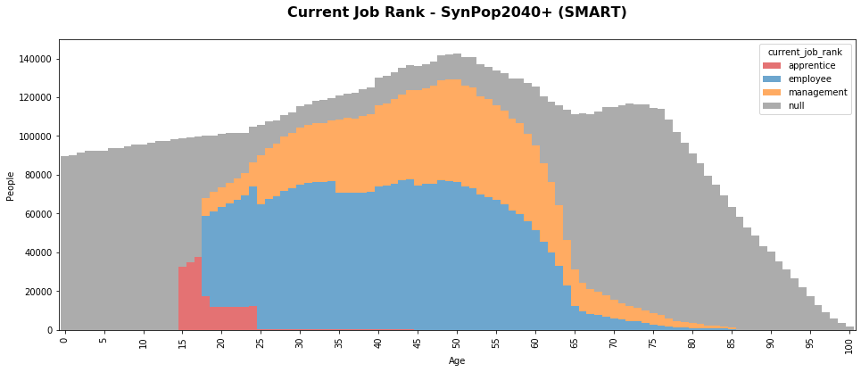

```python
title = f'Current Job Rank - SynPop{YEAR}+ (SMART)'

ax = plot_multi_class_feature_per_age(counts_per_cat_fixed, colour_dict=COLOUR_DICT, ymax=150_000, title=title)

save_figure(SAVE_OUTPUTS, f'04_SynPop{YEAR}Plus_current_job_rank_by_age_SMART.{FIG_FORMAT}',
            OUTPUT_DIR, FIG_DPI, FIG_FORMAT, FIG_BBOX_INCHES, FIG_PAD_INCHES)
```

**Comment on the Results:**

- We achieved what we need for the control total to match later on
- The BFS predictions cannot be matched exaclty because we are not scaling apprentice
- Keeping apprentice stable is done to stay close to the 2017 sctucture.

## Cross-Relationships

**Fixed SynPop**

**CT1**

```
2020-04-22 10:14:42,824 - INFO - root: Figure saved to file : ./outputs\04_CT1_SynPop2040Plus_SMART.png
```

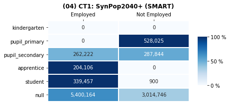

```python
ax, _ = plot_ct1(persons_fixed, title=f'(04) CT1: SynPop{YEAR}+ (SMART)')

save_figure(SAVE_OUTPUTS, f'04_CT1_SynPop{YEAR}Plus_SMART.{FIG_FORMAT}',
            OUTPUT_DIR, FIG_DPI, FIG_FORMAT, FIG_BBOX_INCHES, FIG_PAD_INCHES)
```

**CT2**

```
2020-04-22 10:14:52,870 - INFO - root: Figure saved to file : ./outputs\04_CT2_SynPop2040Plus_SMART.png
```

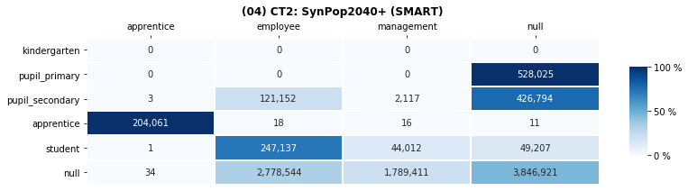

```python
ax, _ = plot_ct2(persons_fixed, title=f'(04) CT2: SynPop{YEAR}+ (SMART)')

save_figure(SAVE_OUTPUTS, f'04_CT2_SynPop{YEAR}Plus_SMART.{FIG_FORMAT}',
            OUTPUT_DIR, FIG_DPI, FIG_FORMAT, FIG_BBOX_INCHES, FIG_PAD_INCHES)
```

**CT3**

```
2020-04-22 10:15:03,815 - INFO - root: Figure saved to file : ./outputs\04_CT3_SynPop2040Plus_SMART.png
```

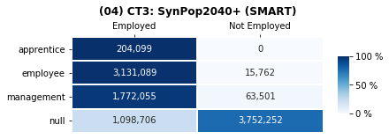

```python
ax, ct = plot_ct3(persons_fixed, title=f'(04) CT3: SynPop{YEAR}+ (SMART)')

save_figure(SAVE_OUTPUTS, f'04_CT3_SynPop{YEAR}Plus_SMART.{FIG_FORMAT}',
            OUTPUT_DIR, FIG_DPI, FIG_FORMAT, FIG_BBOX_INCHES, FIG_PAD_INCHES)
```

# Saving Results

```python
OUTPUT_DIR
```

```
'./outputs'
```

```python
%%time
if SAVE_OUTPUTS:
    results_file = os.path.join(OUTPUT_DIR, 'fixed_current_job_rank_SMART.pickle.gzip')
    fixed_job.to_pickle(results_file, compression='gzip')
```

# Export Notebook to HTML

```python
### Write notebook to a html file
!jupyter nbconvert --to html 04_SMART_Marginal_Fitting_Current_Job_Rank.ipynb
```